# Quality Assurance - Model Maintenance

# 1 Learning Objectives

After this module you will:

- Be aware of general software development best practices relevant to predictive modelling.
- Understand the importance of reproducibility in predictive modelling.
- Understand the implications of how models are delivered on their performance.
- Understand why repeated training is often required for predictive modelling.

# 2 Model Maintenance

We have discussed throughout this course that models do not exist in isolation. They are largely creations of the environment they were built in - as we saw in the ethics module, they also impact the “real world”, and are impacted by the “real world”.

In this module we will explore this interface between the model and the real world.

Analysts, and those interested in predictive modelling, typically focus on the parts that interest them, namely the underlying algorithms and statistical properties. However, exploring models purely from a theory / isolated viewpoint leaves us under-prepared for **actually using the model**.

We should never be creating models for the sake of it, there should be a use case. By thinking about the practical implications of **how the model will be used** we can ensure a more reproducible, valuable solution to our business problem.

Our predictive models will need to… predict something, but how?

Will it be:

- A web application for the general public on “.gov.uk”?
- A one-off analysis for internal business forecasting?
- An automated system deployed within our organisations servers for long term use?

All of the above require different considerations for how our model is looked after.

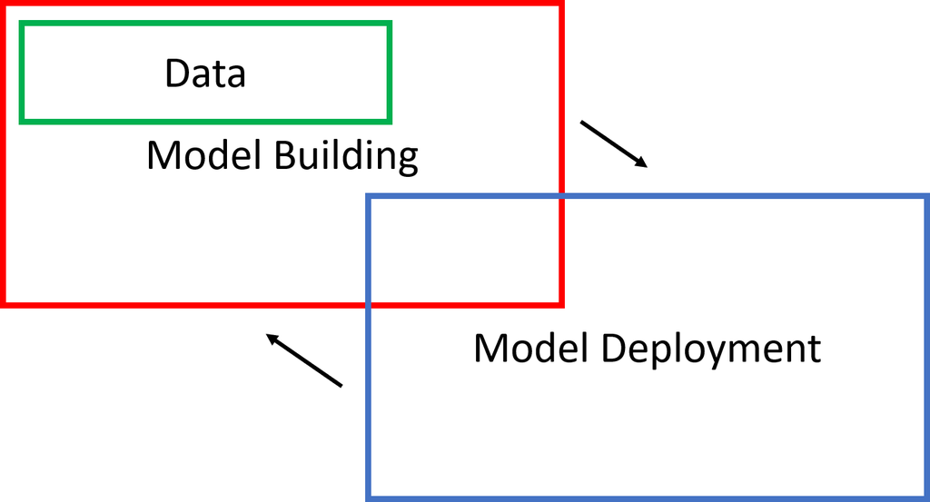

Figure 6.1: Model creation needs to exist in tandem with how the model will actually be used.

For more in depth reading about predictive modelling system design see this open course from Stanford; [Machine Learning Systems Design](https://stanford-cs329s.github.io/index.html#overview).

This page on [MLOps Principles (Machine learning operations) is useful as a shorter read.](https://ml-ops.org/content/mlops-principles)

# 3 General Software Development Good Practice

Predictive models are created using software.

The development of a predictive model system is a form of software development.

The model system has a range of requirements that are met through programming and design. The primary difference with typical software application design and predictive modelling systems is the dependence on data for training. We will address what this difference means for us later.

Therefore all predictive modelling should meet minimum levels of software development best practice.

Thankfully, these good practices are well known in the software development communities, and are therefore accessible to analysts, whether they be data scientists, machine learning engineers, statisticians or anyone else.

[figure not shown]

Figure 6.2: Writing clear code helps everone.

For more in depth training on software development good practice in statistics / data science, see the [Reproducible Analytical Pipeline (RAP) learning pathway on the Learning Hub](https://learninghub.ons.gov.uk/totara/program/view.php?id=6).

## 3.1 Exploration vs Production

Before looking at the actual good practice, it’s important to make a distinction between two different situations:

- A model created for exploration
- A model created for production

The first is used to determine the feasibility of a model, approach or task. The second is **the actual use and deployment of a model**.

Good practice should be followed for both situations, however, how strict the standards are do differ. Proportionality matters, it takes work to bring code to an appropriate standard.

However, often designed models go from being an exploration to production at some point. By following good practice early in this process, this transition becomes much easier.

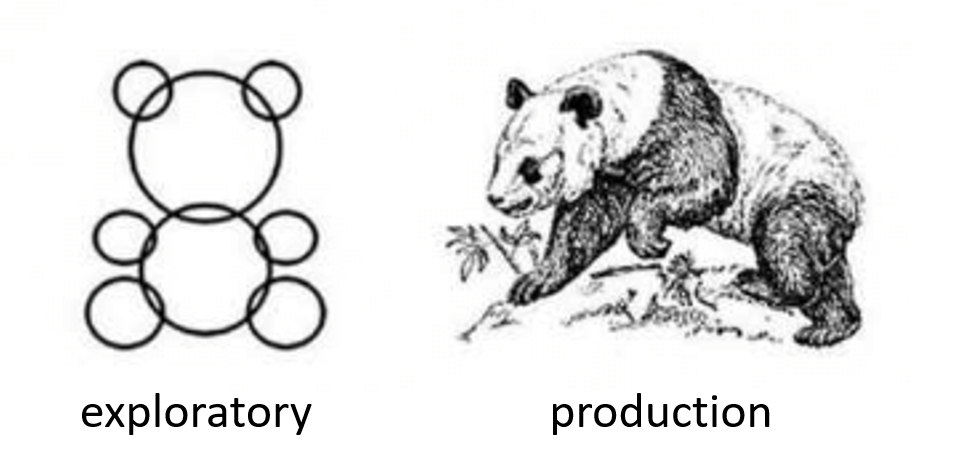

Figure 6.3: Production models are often significantly higher quality code than exploratory. The higher standard the exploratory model is held to, the easier it will be to convert it to production.

The main cause of this difference in approach to standards between the exploratory and production software is that the exploratory approach may not be a final solution. It takes time and effort to **fully** document a process, which can be a barrier in a rapidly changing environment.

Let’s actually look at some conventions now.

**Quality Question**

Is the design approach for this project better as exploratory or production?

## 3.2 Documentation

All of the content covered here is best explained in the [Quality Assurance of Code for Analysis and Research](https://best-practice-and-impact.github.io/qa-of-code-guidance/intro.html) guidance. For this reason, only brief outlines will be provided for the relevant topics. In fact, the [checklists](https://best-practice-and-impact.github.io/qa-of-code-guidance/checklists.html) provided are a great outline for varying levels of code quality.

Documentation is arguably the most important thing an analyst can do.

Code by its nature is difficult to understand. It is a way to condense complex processes into commands.

Documentation allows **humans** to understand what the program will do at appropriate levels of detail.

It’s important that projects are documented at a range of levels. How detailed the documentation is at each level is dependent on a number of factors: is the model exploratory? How early in the design process is the work?

The example levels of code documentation include:

- inline comments
- function / class level document strings
- library documentation
- process diagrams
- desk notes for other analysts
- presentations for stakeholders

Each has a different use, all should be encouraged.

**Quality Question**

How well documented is the code used in this project?

## 3.3 Version Control

Predictive models are a combination of the design decisions and the data used to create them.

The design decisions used to create an individual model can extremely easily be recorded at a minimum level of detail… by keeping the code that was used to create them. The code is a set of instructions which describe how the model was created. By supplementing the code with documentation we can understand **why** the code was created the way it was.

As our model building process changes, so will the code.

**We need to use code version control to avoid losing previous iterations of the model design.**

Version control allows us to roll back to previously overwritten code, and enable improved collaboration and review procedures.

By having specific versions of code at different points in time, we can more easily trace mistakes or decisions in the life-cycle of the development process.

[figure not shown]

Figure 6.4: Example version control workflow ‘Gitflow’. Image obtained from [Atlassian](https://www.atlassian.com/git/tutorials/comparing-workflows/gitflow-workflow)”

**Quality Question**

Is version control being appropriately used for this project?

## 3.4 Testing

A crucial concept, but lesser used depending on background, is the testing of code.

There are a number of ways to test code - starting from the most basic “does it run?”.

As we are looking for quality code in our code bases we need to be able to answer the question:

> “Does the code do what it should?”

This is a non-trivial question.

Code changes over time, the requirements of a project too may change. Manual tests (an analyst running the code to check something) are prone to error and highly inefficient.

By using automated code testing we can quickly assure that the code written meets a range of requirements, at both high (project level) and low (specific lines of code) levels.

Automated testing harnesses testing software to encode the requirements of the project into code.

Testing our code gives us confidence in it’s quality. Without tests we are placing hope in our code. Other quality assurance processes like peer review are helpful, but tests are key.

Testing broadly checks that our expectation of software behavior matches what the software actually does.

On the most simple example we can check whether the output of a function is equal to what we think that output should be.

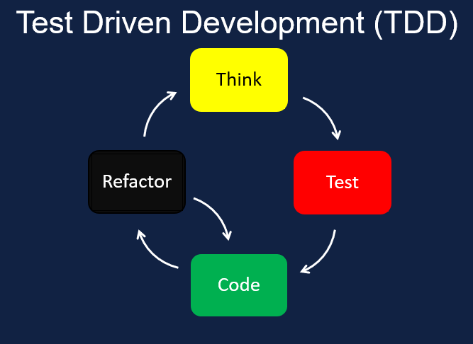

Figure 6.5: Code should pass the tests written for it. If it doesn’t pass it shouldn’t be included in the code base for the project until fixed. A common approach to software development involving tests is called Test Driven Development.

This can be extremely important in modelling, does the complex data transformation we have written actually work? Does the model predict when we would expect for specific examples? What happens when incorrectly formatted data is presented to the model? We can test for realistic situations that our software system may encounter, assuring us they will not fail incorrectly.

**Quality Questions**

What tests might be appropriate for this modelling system?

What degree of certainty to we have that the code does what we think it does?

## 3.5 Discussion

**Question**

Should teams working on predictive modelling systems have a software engineer included?

**Answer**

It’s not a requirement to have a dedicated software engineer in an analysis team.

However, the quality of analysis increases when software best practices are followed. Having analysts familiar with those good practices can be sufficient for some scales of projects.

For larger systems a range of roles may be needed to successfully deliver the predictive modelling product. In this case the team may benefit from software developers, data engineers/architects and their expertise.

# 4 Reproducibility

Reproducibility is crucial in all software for analysis, however, when working with models there are additional considerations required.

Remember: our modelling system is both a model, and its supporting process.

## 4.1 Model Persistence

We have discussed models in a “theoretical” sense so far. They exist, they predict things, they’re maths. But what are they literally?

Models used to predict are software. They are objects written in code which perform tasks. To perform the task they need to be in the computer’s (or server’s) memory to interact with other pieces of code and data.

If we build and train a model, then turn our computer off without saving the model, then that trained model is lost.

The idea of “saving” a model to some form of computer memory, such as a hard drive, is the idea of model persistence.

Model persistence allows us to develop a model, then:

- store it
- share it
- deploy it

This way we do not need to retrain a model every time we want to use it (inefficient at best, impossible at worst).

How can we check that a model has certain properties if we cannot share it and access it? While it may seem obvious that a model should be saved to a file, this is not always the case. Often models are left in the analyst’s code development environment, such as RStudio or Jupyter Notebook until late in the process.

[figure not shown]

Figure 6.6: It’s key that models trained are kept somewhere perminent so that they can be used later, and quality assured without having to recreate the model from scratch.

As we have discussed in the last section, code can change and errors can be added. By writing out a model to a file we can at least give that single model a permanent state.

The specifics of model persistence are beyond the scope of this course, but broadly there are two ways to write a model to memory:

- Using a programming language specific generic object format (for Python this would be a **.pkl** file, for R an **.rds**), useful if you know that the model will only be used using that programming language.
- Using an inter-operable file format such as [ONNX](https://onnx.ai/) or Predictive Model Markup Language [PMML](http://dmg.org/pmml/v4-4-1/GeneralStructure.html) which allow for development across different environments.

**Quality Questions**

How will this model be stored?

Is it securely stored?

## 4.2 Model Versioning

Now that we have written out a model to storage, we now “pin down” specific designs choices into permanent form. The design decisions and data used for that specific model are contained within what we have persisted.

Our model may change over time:

- We create different models over time to evaluate and compare
- We may make different design decisions (preprocessing, hyperparameters)
- We may get more data to train with
- The records the model was trained on may be removed for GDPR or data removal requests

By persisting the models we can access previous iterations of our design for later use. This will help us comparing what we have previously developed without retraining.

As the number of models stored increases it becomes increasingly important that we keep track of what we have created.

Each model created should be accompanied by relevant metadata, for example:

- What code was used to train the model? (reference a version)
- What data was used to train the model?
- When was the model created?
- Comments about the model, links to relevant documentation

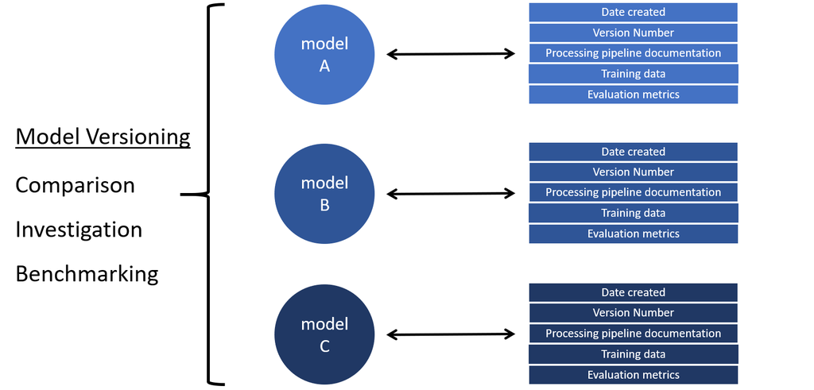

Figure 6.7: Over the course of model design we will create a range of models. By versioning them correctly we can still learn from them after we have created something new.

The metadata could be in a separate file (ideally located near the model!).

This prevents model1, model1a, model_final, model_final2 type issues arising.

How models created are going to be stored, recorded and documented needs to be decided **before** models start being persisted, or there will be an associated documentation debt build up.

While there are some automated production approaches to this challenge, such as [MLMD](https://www.tensorflow.org/tfx/tutorials/mlmd/mlmd_tutorial), for smaller scale projects, or those without the organisational data maturity to support advanced approaches, written documentation and solid naming conventions can go a long way to solving this.

**Quality Questions**

Is there a versioning system in place for models?

How sophisticated is the versioning system?

## 4.3 Data Versioning

We will now complete the trifecta of versioning.

As discussed, our models (versioned) are a combination of… the decisions made that go into it (code/documentation versioned) and the data used to train it.

As versioning the model and code is important, the versioning of data is as well.

Doing this is one of the key differences with traditional software development. In a pure software development setting, the software is the product. In a predictive modelling setting the model, and therefore the data are the products.

Our training data can change over time, we may:

- have new training data made available
- alter the processing of our original training data
- need to remove certain records in our training data (such as a result of a right of removal request)

This means we cannot have one single data set / database that is updated over time, **and** be able to link specific models with their training data sets.

There are a range of options for versioning data, the right approach will depend on the size, how it is hosted and how much it changes.

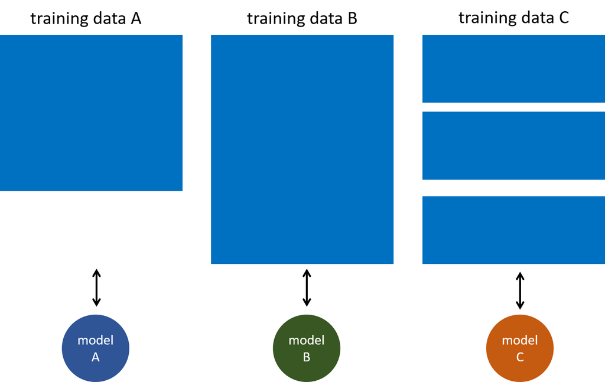

Figure 6.8: With different data, we will get different models. It is therefore crucial we can trace back for every model what data it was trained with. By versioning the data, rather than continuously updating or removing it, we can do this.

One option is to use a versioning system, similar to git (used for code bases), called [Data Version Control (DVC)](https://dvc.org/). When combined with an appropriate hosting platform this can streamline the process.

A more manual, but broadly applicable approach would be by naming the files used to train the data following an informative convention. By adding a data dictionary that gives information about each data set we can then keep track of changes the data more easily.

Once we have the code, data and model versioned, we will have a **much simpler time reproducing results** which will improve our quality assurance process.

One thing to know about versioning data is that there are often multiple steps in creating training data.

The original data may come from a query in a data base, then loaded and transformed in a variety of ways, before being fed to the model. Ideally the original data and the transformed data are preserved and versioned, but at minimum the final training data needs to be kept, with a record of how it was obtained.

[figure not shown]

Figure 6.9: When there are many different steps in the data processing pipeline we need to be careful about keeping the original data. At minimum we need to have the final step of the training data used for the model.

**Quality Questions**

Is there a versioning system in place for data?

How sophisticated is the data versioning system?

Is the data versioning system compliant with GDPR?

## 4.4 Experimentation and Evaluation Metrics

Predictive modelling, due to it’s nature, is experimental. We don’t know how well a model or design approach will perform until we actually measure it.

For that reason it is crucial we keep track of the methods used and their results of our experiments.

This allows us to compare designs and learn from past decisions. This helps us avoid repeating approaches that have already been tested, and to see what has already been attempted.

Our experiment tracking should answer some of (but not limited to) the following questions:

- What model was run?
- How did the model perform?
- When was it run?
- What configuration of the model / processing was used?

[figure not shown]

Figure 6.10: Example model comparison using Tensorboard. The models will produce data themselves and the analysis of it is useful for both the design and quality assurance of the process

As with the persistence of models (saving the model to storage), the results of our experiments need to be permanent. Therefore it is useful to have the model system produce its own results, such as writing evaluation scores, models and data versions out to a file.

At minimum, the experimental results we produce can be ‘written’ by hand, or automatically written out or “logged” to a file. This helps tie together the different elements of reproducibility.

More advanced approaches include other software systems that allow you to manage the tracking of experiments such as [MLFlow](https://mlflow.org/), [Tensorboard](https://www.tensorflow.org/tensorboard) and [guild.ai](https://guild.ai/).

**Quality Questions**

How are the different versions of the models compared?

Where are the performance metrics for each model kept?

## 4.5 Discussion

**Question**

Can a project be successful without versioning code, data and models?

**Answer**

A project may be successful without following all these good practice conventions. However, by not following the conventions the risks are greater. Poor quality is more likely to exist in the project which will impact on the delivery.

The level of good practice to follow should be proportionate to the task. Fully automated infrastructure to support design and delivery can be appropriate, but only for large scale projects that are frequently updating. Clear documentation can solve a lot of the challenges for smaller projects.

Good documentation, and keeping records are crucial for accountability and audit. Version control of the things the documentation discusses can therefore help us ensure the code/data/models align with what has been described.

# 5 Delivery

It’s crucial that when we design and review a model we always keep in mind that the predictive model **is going to be used**. It is not an academic piece in of itself, it has a purpose and will be used.

Because this is not some model for modelling sake, the system will interact with the wider world not just within our computer. We will need to design, monitor and improve how this interaction happens.

If we do not plan for how our model will actually be used, we will not get the value from it we want.

## 5.1 Model Usage

We are going to use the model to make predictions? Sorted, that’s that then.

Not quite.

The actual mechanics of how a model will make the prediction is an important step in the design process, as it’s consequences can be far reaching.

This topic strays into an area called Machine Learning Operations (MLOps), or Development-Operations (DevOps. A more software-engineering area, which is less studied by those of an analytical background.

We need to be able to answer the following questions when actually using a model, once it is created:

- On what system will the model be stored? (on my laptop? on a server? in the cloud?)
- Who will be responsible for monitoring it? (will the team that created it will be responsible for it’s use)
- Who will interact with the model for it’s predictions? How will they give it data to make predictions for?
- What happens to the predictions once they are made?

We will explore two ends of the automation spectrum for the deployment of our predictive model.

1.) Manual Deployment

The model is stored as a file on an analyst’s laptop.

Records for which predictions are needed are emailed over to the analyst.

The analyst loads up their code editor, loads the model onto their computer’s memory. They load in the data, clean it a bit then give it to the model for prediction.

The data and predictions are joined together and written out as **predictions.csv** and sent back to the person who requested the prediction. If there aren’t too many predictions, the analyst can look through the predictions to check whether anything has gone wrong.

There are some issues with this approach:

- It’s slow, it requires a lot of manual work from the analyst. Time per prediction can be quite large considering the process is all computer based.
  - A batch can be processed, but if there are lots of batches or data, or a continuous stream this may be prohibitive.
- It’s error prone, if the data is incorrectly formatted, or the analyst does a step wrong it will produce either no predictions (code fails) or incorrect predictions (for example, what if the order of columns in the data changes).
- It is dependent on an individual, what if the analyst has a day off, or their team has other priorities?

However, the approach has one main upside: it does not require supporting IT infrastructure or operational knowledge, hence why it or something like it may be common.

[figure not shown]

Figure 6.11: Just like in general analysis pipelines, manual steps are inefficient and prone to error. Manual processes for deployment are appropriate when the infrastructure to deploy is too much overhead/investment.

2.) Automated Deployment

The model is stored on a server/cloud service.

The user goes to a specific website/address, completes some action causing the model to generate a prediction. The system records what the prediction was used. The user gets the prediction they wanted (or it happens to them).

An analyst can at some point look at the predictions made, exploring the results.

As the model is part of a software system the input data can be validated and rejected if needed. The predictions can be checked to make sure they meet certain expected conditions. All actions can be recorded as log data, ready for inspection later.

In this system we may be able to generate many more predictions at a time or over time than using an approach dependent on an individual.

In contrast to the manual system:

- The system is as fast as the code we can optimise, rather than how quickly the analyst can reply to an email / run code.
- We can automate checks for input data and output predictions.
- We have an audit trail of data telling us what happened for each prediction / user, rather than relying on the analyst making notes.

[figure not shown]

Figure 6.12: Automation can bring some degree of assurance, allowing minimum standards to be met and records to be kept, while reducing the analyst’s time spent for each prediction.

**What’s key here is that there is no big button called “deploy” we press at the end of designing the model without thought.**

There are benefits and downsides for each type of deployment. Massive online companies will have highly automated processes for their model deployment (think: Netflix suggested content), more research / academic institutions may use a more lightweight manual approach. We need to decide what is appropriate for our task, and in addition what can help ensure **quality**.

As with other pipeline building tasks, it should be considered how frequently a process will be used before creating a data infrastructure to support the process. A one-off batch of predictions shouldn’t require a fully automated pipeline, but a model used every day does.

**Quality Questions**

Is the way the model is going to be deployed fit for purpose?

How will the deployed model be supported?

## 5.2 Monitoring

For a moment, lets assume something about our model:

- It is a good solution to the problem it is designed to solve, given the constraints imposed.

This is more than likely true, so we start using the model in a system, automated or otherwise.

However, we have made one significant **hidden** assumption there.

We only know that the model was good based on the data we trained/evaluated it with **at the given time of evaluation/training**.

We cannot assume that the model will be as good forever in the future.

The model is modelling populations / dynamic processes that will change with time, they are likely not to be static.

A machine learning model that predicts air traffic volume trained on data from 2010-2019 will perform poorly in 2020-2021 because of the Covid-19 pandemic. The fundementals of the underlying data system have massively changed and we need to be able to monitor that change!

It is therefore crucial that our modelling system is able to measure how well the model is performing at any given time, as this performance is not guaranteed to match the initial performance during the design phase.

When the model comes into contact with the real world it will perform differently to “in our lab”. We only know how differently by measuring this.

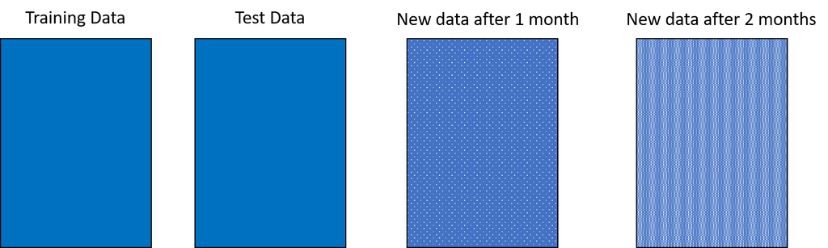

Figure 6.13: The data we train and evaluate with may be correct at the time of the model being created, but new data may have different properties, which will change how our model performs.

There are broadly 3 different things we want to monitor for a deployed model:

1.) Stability - how stable is the data we are using to predict changing?

- The distribution of predictions may change over time compared to the training data
- The distribution and covariance of features may change over time when compared with the training data

2.) Performance - how good is the model at predicting?

- The value of our performance metrics (such as precision and recall) may be changing over time, we will need ground truth data to test this.

3.) Operation - how is our system performing from a deployment perspective?

- The model may be taking up lots of memory, or be overwhelmed with requests or even taking a significant amount of time to generate predictions.

Thankfully, we are using a software system, so we can automate many of these processes. Some example tests we might continuously run are:

- Check for predictions of NaNs or infinities
- Check the average prediction bias is near zero
- Check the predictions are within some reasonable size/magnitude

**Quality Questions**

What monitoring metrics would be useful for this model?

What levels of performance should cause concern?

## 5.3 Concept Drift

Monitoring the data given to a model and the performance of a model are crucial, systems and populations are rarely static.

When the data we are using is changing its characteristics over time in comparison to the data we trained the model with, we refer to this as **concept drift**.

For example, if customers buying habits change over time - they are buying sorbet more and more rather than ice-cream, this can cause our model to become increasingly incorrect.

More extreme examples of shifts could be large scale phenomena such as covid disrupting predictions like flight purchases, hospital capacity prediction and online commerce. These changes may be permanent or rapidly changing, each impacting the “old” model’s performance.

In the below figure we have an example of concept drift. Over time the cells features are changing. The mean value for some features are increasing, some decreasing.

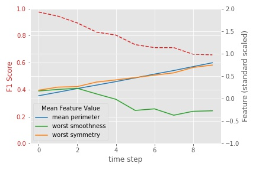

Figure 6.14: The model has been trained on a specific data set, and is good at predicting data of that form. If the data it needs to predict for changes the the model will make more incorrect predictions.

If we are using a standard scaler in our model, that will have saved the mean and variance of our features. These characteristic values are now changing, so our scaling is going to be incorrect too!

We can tell if there is concept drift by investigating the incoming data in batches. If the sample at a specific time has significantly different characteristics to our training data we should raise a warning!

We can only tell if this concept drift is **having an effect on performance** if we have ground truth labels for the new data coming in. This means we will need to have some way of verifying whether a new prediction is correct, even after our model is trained.

With the new ground truth data we can determine if our model is still fit for purpose, or if we need to change it in some way, the subject of the next section.

**Quality Question**

How is concept drift going to be measured?

## 5.4 Discussion

**Question**

How do we know if a model is predicting badly without ground truth data?

**Answer**

We cannot know if a model is performing badly in the absence of ground truth data. There are some measures we can use to gauge deviation such as measure prediction bias or underlying data dirstributions, but ultimately we need true test data to measure if the model has dropped performance.

# 6 Retraining

## 6.1 Stale Models

So, as the underlying data and systems that the model is modelling change, the original model becomes stale. It’s performance will often degrade over time*.

Not always, depending on what is being modeled.

This means, should we be using a system over a period of time, that we need to consider how to mitigate this performance degradation.

**Even if the model is only used once a year, if the underlying system/data has changed in that year we need to evaluate the model against new data to determine if it is still appropriate to use.**

To appropriately maintain the model we need to:

- **Evaluate its changing performance (with new ground truth data)**
- Determine if the new performance is still good enough
- If not good enough, update the model to meet our needs.

Without evaluating the model with new data, we cannot know whether it is stale or not.

The model may still perform *okay* with the new process it is modelling, but it will not be optimal. There is a cost in updating a model, depending on the frequency, which needs to be kept in mind.

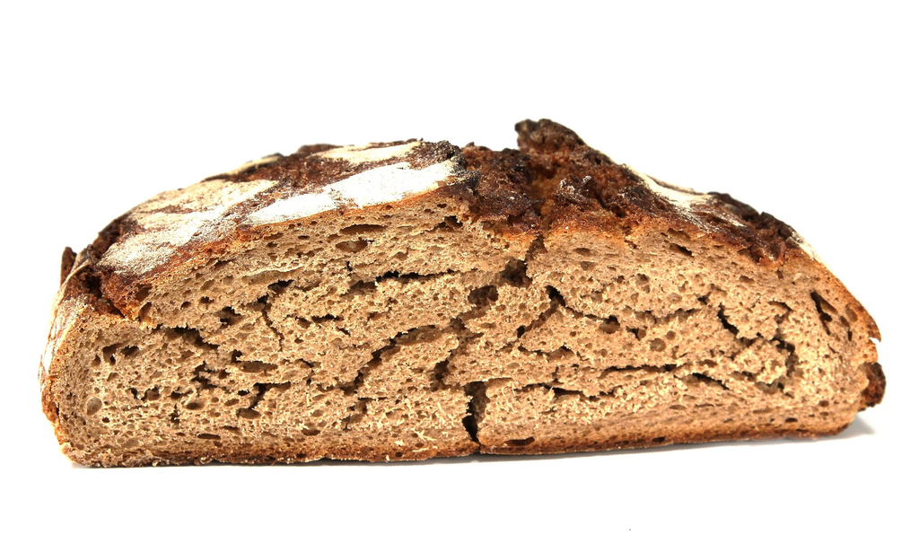

Figure 6.15: Models, like bread, can go stale over time. If we leave a model long enough it will not be as good as when we created it. We need a way to freshen it up after a period.

**Quality Question**

What processes are in place to prevent stale models being used?

## 6.2 Refresh

There are a number of ways we can update/refresh a predictive model that is becoming stale.

This is a much larger topic than the scope of this course, so we will just mention different approaches for awareness and how they help solve the problem.

### 6.2.1 Retrain

The first option we have is to take our original model - and chuck it.

We can create a new training set with new data more representative of the current patterns (or with a mix of new and old data), and train a new model.

We could create the new model by:

- Using the exact same design approach as previous
- Using the same model type but search for the best hyper-parameters
- Starting the model selection from scratch

This model will, hopefully, better represent the current state of the system the model is trying to predict from.

The new model will likely not be **hugely** different from the original model, the patterns will be partially different.

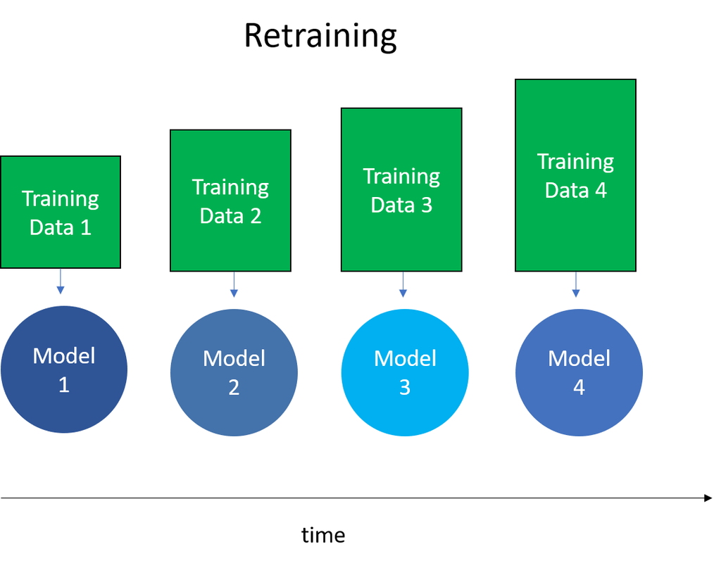

Figure 6.16: Each time we retrain the model we get a completely new model. It will find different patterns. We can decide how much of the historic data to train it on, this example shows the new model being trained on all of the historic and new data. Depending on how stale the old data is, we may choose to exclude it.

There are some trade-off with this approach.

Good:

- Easy to understand
- Available to all model types

Bad:

- This may be computationally expensive/inefficient especially for large models

Once we have retrained a model, it needs to be evaluated robustly before being deployed, as our original was.

**Model versioning** becomes very important as we update the model we are using. We can roll-back to previous versions of models if needed.

We may even want to automate this retraining process, if our infrastructure is adequate and our quality assurance tests are robust enough. [This article contains more recommendations on model retraining](https://community.tealiumiq.com/t5/Tealium-Predict-ML/Model-Retraining-Recommendations/ta-p/33508#toc-hId-586153860).

### 6.2.2 Online Models

Not all models need to be trained from scratch.

Some classes of models can be trained on a set of data, then also trained on a second set, then third over time.

Models of this type are referred to as “online”, not necessarily because they are hosted online, but because they are always trainable. They can leverage prior training on new data.

This introduces more efficiency in the training process. If it is not feasible for us to retrain from scratch (our model may take too long to train for example), then we may want to choose an “online” learning algorithm.

Instead of “full” retraining, online algorithms are effectively “partially” trained at each step. This approach is often called “incremental” training or continuous learning.

Although we are updating an existing model, it’s important we keep **versioning the models!**.

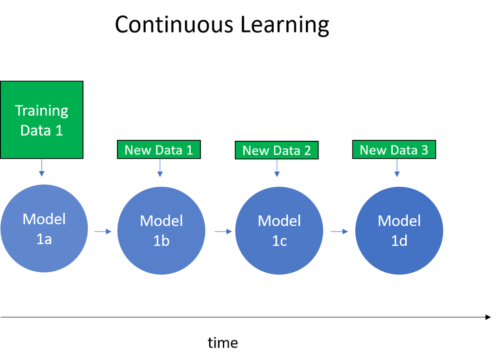

Figure 6.17: With incremental/continuous learning our model can be fed new streams of data to improve the performance over time. This can also work well for unsupervised learning tasks, such as recommender engines.

Some example online learning algorithms are:

- Naïve Bayes
- Stochastic Gradient Descent (SGD)

Again, there are trade-offs to this approach.

Good:

- Easy to update model with new data
- Efficient use of computer memory (not all data needed in memory at once)

Bad:

- Only available for some learning algorithms
- The algorithms available may not be the best performing
- Changing design process will still require retraining

## 6.3 Challenges of Retraining

The benefits to retraining our models are clear, as models age* they generally perform worse.

The time scale on which they age depends on how quickly the real world data being modeled changes.

However, it’s not trivial to retrain a model. There are a number of requirements we need to meet before we can do it:

- We have an individual or system able to run the model training.
- we have new data that is labelled appropriately and accurate.
- We know **when/at what point** to retrain the model. This may be periodic, or only when performance reaches a certain level.

Which means we really need to be prepared for retraining when we first start to use a model. There’s little point investing in a model that will degrade quickly if there is no plan for how to retrain and maintain it in the future.

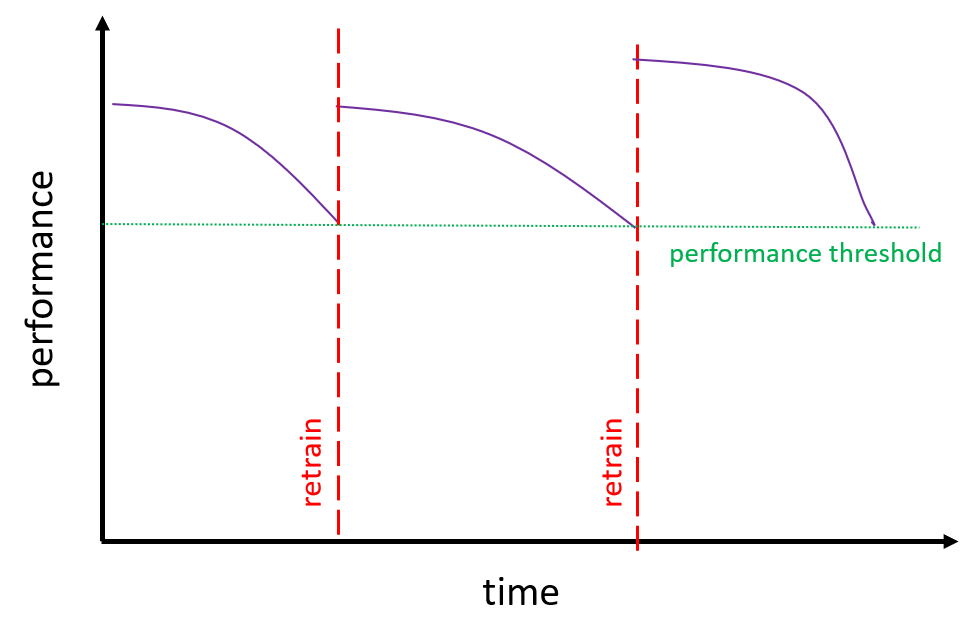

Figure 6.18: We need to be able to measure the model’s performance in some way, then make changes to it when needed. Ideally we can measure in near-real time what the performance is, but the most important thing is it being measured. By retraining we avoid substantial losses in performance.

As with all elements of having a model in production, we need to put in the resources to maintain the system in order to get the best value out of the model.

Some challenges in retraining a model include:

- Collecting new labelled data
- Knowing when to retrain the model
- Having the expertise to automate retraining if appropriate

The best way to mitigate these challenges… is to plan for them!

The question of who is responsible for the deployment and/or maintenance of a modelling system is really key, the team needs to have the skills to support the system, regardless of how advanced it is.

**Quality Question**

How frequently will the model be retrained?

Is the frequency of retraining justifiable? Think about the resource/environmental cost for marginal performance gain.

## 6.4 Discussion

**Question**

If an individual who’s data was used to train the model asks for their data to be removed, do we need to retrain the model?

**Answer**

Yes! Although the model itself may not be the exact data given by the user, it is effectively processed data. This means models need to be refreshed when the data used to train them is removed for privacy reasons.

If using personal data to train a model, a plan needs to be in place for how to handle this situation. Will there be a new model for every record removed?

# 7 Summary

Model maintenance is a crucial part of predictive modelling. It includes the practical elements of *how is the model going to be used* and *how is it going to be looked after*. These are questions that really need to be addressed early in the design and specification process.

As the predictive modelling system is built on software, we must follow software design good practices. To build assurance in our process we should be documenting code well, versioning it for later use and writing tests to ensure our expectations meet the reality of what we have made.

Beyond software design good practice, there are a range of issues that arise specifically for predictive modelling systems. We need to ensure that our solution is reproducible, which helps with review. This is done by ensuring we persist models, version the data used to create models, version the models themselves and keep track of the performance of the models.

*How* the model is going to be used will impact a lot of decisions about it and its long term requirements. As the model is used we need to ensure that it still fits purpose.

At some point the model may deviate in performance enough, or the underlying data may change, such that we need a new version of the model to solve tackle our task. It’s important that we don’t let models become stale, as it reduces their quality.

Model deployment and maintenance often requires a different skill set to that of model design - yet another reason to have a range of individuals part of the process of a predictive modelling system.